# Building a Scorecard

Predicting bads using Logistic Regression

Thomas Beeson

31 May 2021

# 1 Introduction

## 1.1 What is the problem?

It is important for companies that offer loans to be able to identify (at the point of application) applicants who are potentially bad (will default on their loan) to minimise the losses occurred when writing off loans.

## 1.2 The data

The data for this project can be found below. The data contains 74 variables and 897,379 observations. The key variables upon observation are the following:

- delinq_2yrs – we can use this to derive a bad definition
- term – product term
- emp_length – employee length
- inq_last_6mths – inquiries over last 6 months
- annual_inc – annual income
- int_rate – interest rate on loan
- home_ownership – e.g. mortgage, rent
- grade – assigned loan grade
- loan_status – current position of the loan

https://www.kaggle.com/wendykan/lending-club-loan-data

## 1.3 How will we tackle the problem?

I found this really useful graphic which illustrates the process we’re going to undertake. An explanation into each step is found below too.

- Fine classing: Process of putting data into buckets or intervals.
- Coarse classing: Process of merging buckets or intervals that are similiar.
- WoE: Weight of Evidence, technique applied when we have a binary response variable. It tells us the predictive power of a predictor in relation to our response variable. As it’s commonly used in credit industry for scorecard building, it’s usually defined as a measure of the separation of good and bad customers. The calculation for WoE is below;

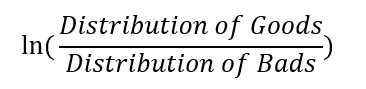

- Train model: Process of creating a model to predict bad’s on a training set.
- Score: Create a score which is associated with the likelihood of an observation going bad.
- Validate: Process of validating that the model is successful on test data.

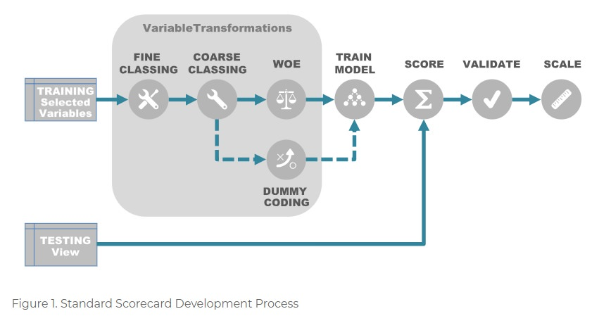

# 2 Preliminary steps

In this section, we import the libraries we will be using, import our datasets and also look briefly at the variables within the dataset.

## 2.1 Import libraries

```r
if (!require("dplyr")) install.packages("dplyr"); library(dplyr)
if (!require("Amelia")) install.packages("Amelia"); library(Amelia)
if (!require("ggplot2")) install.packages("ggplot2"); library(ggplot2)
if (!require("reshape2")) install.packages("reshape2"); library(reshape2)
if (!require("corrplot")) install.packages("corrplot"); library(corrplot)
if (!require("tidyr")) install.packages("tidyr"); library(tidyr)
if (!require("caret")) install.packages("caret"); library(caret)
if (!require("sqldf")) install.packages("sqldf"); library(sqldf)
if (!require("tidyverse")) install.packages("tidyverse"); library(tidyverse)
```

## 2.2 Import data

```r
setwd("D:/Kaggle Datasets/loan_club")
df <- read.csv("loan.csv")
```